# Human Activity Recognition

Alexander N. Villasoto

19 November 2018

```r
knitr::opts_chunk$set(echo = TRUE)
knitr::opts_chunk$set(cache = TRUE)
knitr::opts_chunk$set(message = FALSE)
knitr::opts_chunk$set(warning = FALSE)
knitr::opts_chunk$set(fig.align = "center")
knitr::opts_chunk$set(fig.show = "hold")
```

## I. Synopsis

Due to the recent trend in the usage of commodity hardware that monitors human activity the likes of Apple Watch and Fitbit as well as the prevalence of inexpensive hardware that collects massive and real-time data, several researchers particularly Ugulino et. al. sought the need to explore Human Activity Recognition (HAR) studies that they collected movement data based on 5 classess of motion (sitting-down, standing-up, standing, walking, and sitting) on 8 hours of activities of 4 healthy subjects.

Building upon the efforts put behind this research, the author did a predictive analysis project with the following parts - (1) exploratory data analysis, (2) model building and (3) model performance analysis with ensemble modeling that would ultimately realize a best model that predict a type of activity based on the pertinent covariates.

The author exrtracted 25 covariates from the raw data that would explain 95% of the total variation throught Principal Component Analysis, divided the resulting analytic data into training and testing and building a machine learning model across common algorithms including (1) Decision Tree, (2) Decision Forest, (3) Naive Bayes, (4) Optimized Gradient Boosting, (5) Polynomial Support Vector Machine and (6) Neural Networks.

Analyzing the result of modeling, the author observed that random forest and gradient boosting got the highest average accuracy across 10 cross-validations using the test dataset. He then used these to generate an ensemble model with random forest as an aggregating method that also reported low out-of-sample errors, the same as the random forest.

Random Forest and ensemble methods report pretty good out-of-sample errors under generalized training parameters, deeming these as the best model for this scenario. In the Human Activity Recognition, the author err on the side of simplicity that is why the author chose random forest model to predict 20 unlabeled observations, ultimately concluding that it is possible to predict classes of movement from out-of-sample observations based on the given data.

```r
# libraries
library(dplyr)
library(caret)
library(ggplot2)
library(reshape2)
library(pROC)
library(MLmetrics)
library(gridExtra)
```

## II. Exploratory Data Analysis

In this section, the author loads necessary libraries for model-building, data visualization, and model analysis. Main sections include (1) load dataset, (2) clean data, (3) split data into training and testing, (4) employ principal component analysis and (5) print correlation matrices.

### A. Load Dataset

```r
# set working directory
setwd("~/Projects/Courses/Coursera/Practical Machine Learning/Human-Activity-Recognition/")

# read csv
train.data.raw <- read.csv(file = "data/pml-training.csv")
test.data.raw <- read.csv(file = "data/pml-testing.csv")
```

### B. Clean Dataset For Training

```r
# Data Cleaning

# Select columns with complete cases:
# class of each column in dataset
col.class <- sapply(train.data.raw, class)
# show unique classes
unique(col.class)
```

```
## [1] "integer" "factor"  "numeric"
```

```r
# check columns with an acceptable amount of values with complete cases
# (non-null and non-empty values)
# acceptability in this case means that the number of values in the column
# with complete cases is greater than or equal to 90% of the total observations
# in the dataset.
get.col.indexes.with.complete.cases <- function(data) {
  data %>% sapply(function(x) {
    if (is.numeric(x)) {
      # for numeric columns
      # check if a reasonable amount of values in the column have complete cases
      # if yes, return true, else return false
      if (sum(complete.cases(x)) >= (length(x) * 0.9)) {
        TRUE
      } else {
        FALSE
      }
    } else {
      # for factor columns
      # check if reasonable amount of values in the columns have complete cases
      # AND not equal to empty string
      # if yes, return true, else return false
      if (sum(complete.cases(x)) >= (length(x) * 0.9) &
          sum(x != "") >= (length(x) * 0.9)) {
        TRUE
      } else {
        FALSE
      }
    }
  })
}
# reduced train dataset (columns with acceptably complete cases)
train.data.complete.cases.index <-
  get.col.indexes.with.complete.cases(train.data.raw)
train.data.reduced <- train.data.raw[, train.data.complete.cases.index]

# for 20 unlabeled observations
unlabeled.data.reduced <- test.data.raw[, train.data.complete.cases.index]

# removing unnecessary covariates
train.data.reduced[1:5, 1:7]
```

```
##   X user_name raw_timestamp_part_1 raw_timestamp_part_2   cvtd_timestamp
## 1 1  carlitos           1323084231               788290 05/12/2011 11:23
## 2 2  carlitos           1323084231               808298 05/12/2011 11:23
## 3 3  carlitos           1323084231               820366 05/12/2011 11:23
## 4 4  carlitos           1323084232               120339 05/12/2011 11:23
## 5 5  carlitos           1323084232               196328 05/12/2011 11:23
##   new_window num_window
## 1         no         11
## 2         no         11
## 3         no         11
## 4         no         12
## 5         no         12
```

```r
train.data.reduced <- train.data.reduced[, -c(1:7)]
unlabeled.data.reduced <- unlabeled.data.reduced[, -c(1:7)]

# Clean Train Data
train.data.cleaned <- train.data.reduced %>%
  filter(complete.cases(.) & sum(is.na(.)) == 0)
```

### C. Split Data into Training and Testing

```r
# divide the train.data.reduced into training and testing 75/25
training.index <- createDataPartition(y = train.data.cleaned$classe,
                                      p = 0.75,
                                      list = FALSE)
training <- train.data.cleaned[training.index, ]
testing <- train.data.cleaned[-training.index, ]

# print first 5 values of training set
head(training)
```

```
##   roll_belt pitch_belt yaw_belt total_accel_belt gyros_belt_x gyros_belt_y
## 1      1.41       8.07    -94.4                3         0.00         0.00
## 2      1.41       8.07    -94.4                3         0.02         0.00
## 3      1.42       8.07    -94.4                3         0.00         0.00
## 4      1.48       8.05    -94.4                3         0.02         0.00
## 5      1.48       8.07    -94.4                3         0.02         0.02
## 6      1.45       8.06    -94.4                3         0.02         0.00
##   gyros_belt_z accel_belt_x accel_belt_y accel_belt_z magnet_belt_x
## 1        -0.02          -21            4           22            -3
## 2        -0.02          -22            4           22            -7
## 3        -0.02          -20            5           23            -2
## 4        -0.03          -22            3           21            -6
## 5        -0.02          -21            2           24            -6
## 6        -0.02          -21            4           21             0
##   magnet_belt_y magnet_belt_z roll_arm pitch_arm yaw_arm total_accel_arm
```

[output cut: 69 more lines]

### D. Correlation Heatmap and Principal Component Analysis

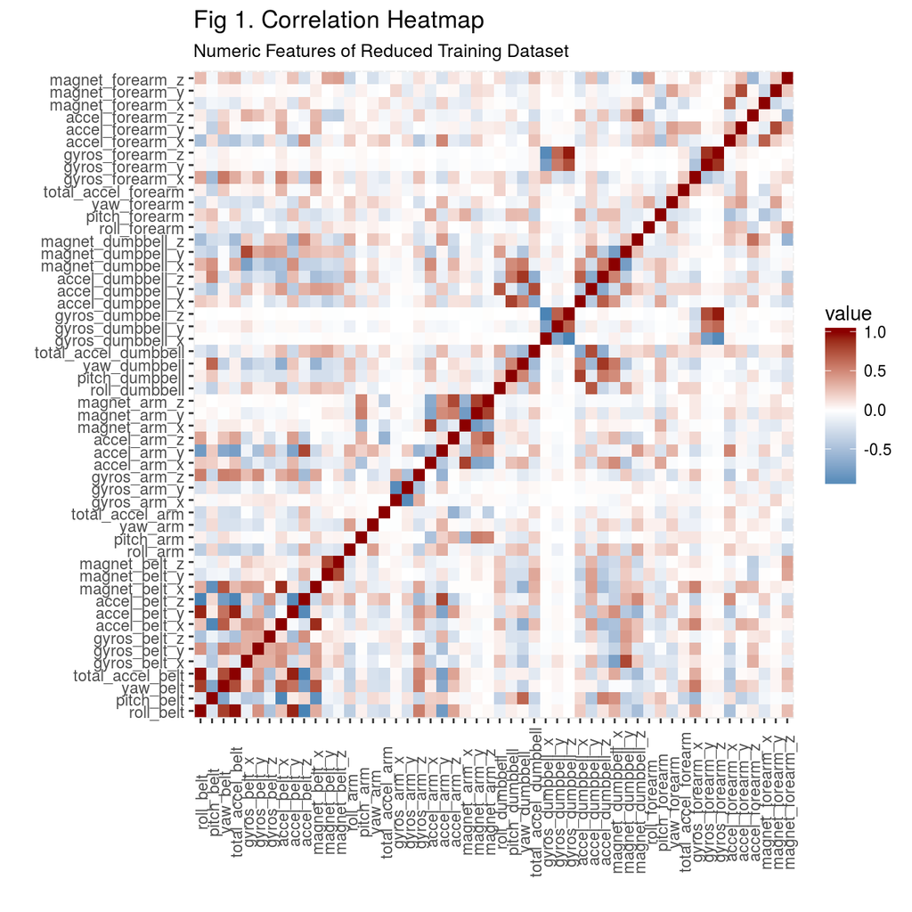

```r
# Correlation Heatmap
plot.correlation.heatmap <- function(data = training,
                                     title, subtitle) {
  correlation <-
    round(cor(subset(data, select = sapply(data, class) != "factor")), 2)
  # Melt data to bring the correlation values in two axis
  correlation.melted <- melt(correlation)
  ggplot(data = correlation.melted,
         aes(x = Var1, y = Var2, fill = value, label= value)) +
    geom_raster() +
    scale_fill_gradient2(low = "steelblue",
                         high = "darkred",
                         mid = "white") +
    theme(axis.text.x = element_text(angle=90, vjust = 0.6),
          axis.text.y = element_text(vjust=  0.6)) +
    labs(title = title, subtitle = subtitle, x = "", y = "")
}
# plot correlation heatmap of training dataset
plot.correlation.heatmap(
  data = training,
  title = "Fig 1. Correlation Heatmap",
  subtitle = "Numeric Features of Reduced Training Dataset"
)
```

Looking at the correlation heatmap (outside the identity line), we see that there are highly correlated variables (dark red and dark blue shades representing strongly positive and strongly negative correlation respectively). Including unnecessary variables in modeling will definitely increase the R squared but will suffer from the increase in the variance of the variance estimate, meaning that we included regressors that are linear combinations of other covariates. To remedy the situation, the author employed Principal Component Analysis across numeric covariates like so:

```r
preprocess.pca <- preProcess(x = subset(training, select = -classe),
                             method = "pca",
                             thresh = 0.95)
# print the result of pca
preprocess.pca
```

```
## Created from 14718 samples and 52 variables
##
## Pre-processing:
##   - centered (52)
##   - ignored (0)
##   - principal component signal extraction (52)
##   - scaled (52)
##
## PCA needed 25 components to capture 95 percent of the variance
```

As we can see, 25 principal components capture 95% of the total variance. Since that is the case, he then applied that preprocessing to our training, testing and unlabeled dataset (we do not know the real label, we are just reporting the result of prediction utilizing the best model). He also print the correlation matrix for the training dataset using only the principal components.

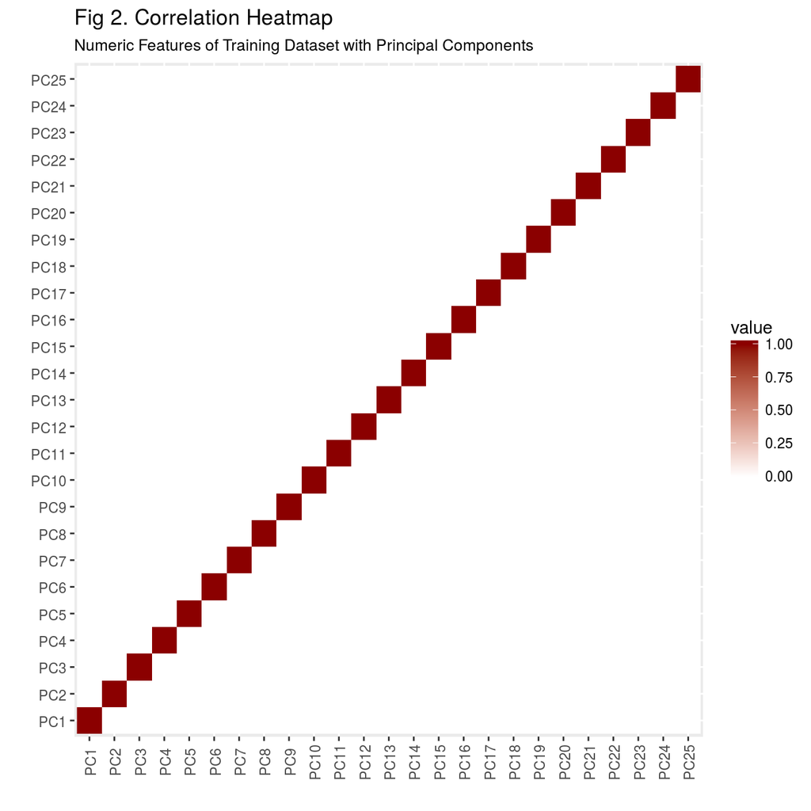

```r
# for training
train.pca <- predict(object = preprocess.pca,
                       newdata = subset(training, select = -classe))
train.pca$classe <- training$classe

# for testing
test.pca <- predict(object = preprocess.pca,
                    newdata = subset(testing, select = -classe))
test.pca$classe <- testing$classe

# plot correlation heatmap of training dataset with resulting principal
# components
plot.correlation.heatmap(
  data = train.pca,
  title = "Fig 2. Correlation Heatmap",
  subtitle = "Numeric Features of Training Dataset with Principal Components"
)
```

## III. Model Building

### A. Establish Training Parameters

```r
# training parameters use repeted cross-validation with 10 folds. This is to
# make sure that the model generalizes well on new data and
# separate signal from noise.
training.parameters <- trainControl(method = "cv", number = 10)
```

### B. Model Building

```r
# function that generates training model, prediction, confusion-matrix and
# out-of-sample error
train.and.predict <- function(model.method = "rpart", train.data = train.pca,
                              test.data = test.pca,
                              training.parameters = training.parameters) {
  model <- list()

  # train
  if (model.method == "svmPoly") {
    # since polynomial svm needs tuneGrid extra parameter, its model is
    # separated from others
    model <- train(classe ~ .,
                   data = train.data,
                   method = model.method,
                   trControl= training.parameters,
                   tuneGrid = data.frame(degree = 1,
                                         scale = 1,
                                         C = 1),
                   na.action = na.omit)
  } else if (model.method == "nnet") {
    # since neural network prints verbose messages per iteration,
    # its modeling is separated from others
    model <- train(classe ~ .,
                   data = train.data,
                   method = model.method,
                   trControl= training.parameters,
                   na.action = na.omit,
                   trace = FALSE)
  } else {
    # for remaining methods
    model <- train(classe ~ .,
                   data = train.data,
                   method = model.method,
                   trControl= training.parameters,
                   na.action = na.omit)
  }

  # predict
  predictions <- predict(object = model,
                         newdata = test.data)

  # generate confusion matrix
  confusion.matrix <- confusionMatrix(data = predictions,
                                      reference = test.data$classe)

  # out-of-sample error
  out.of.sample.error <- (1 - confusion.matrix$overall["Accuracy"])

  train.and.predict.object <- list("model" = model,
                                   "predictions" = predictions,
                                   "confusion.matrix" = confusion.matrix,
                                   "out.of.sample.error" = out.of.sample.error)

  train.and.predict.object
}

# List of Model Methods to Build
# (1) Decision Tree
# (2) Decision Forest
# (3) Naive Bayes
# (4) Optimized Gradient Boosting
# (5) Polynomial Support Vector Machine
# (6) Neural Networks

# (1) Decision Tree
dtree <- train.and.predict(model.method = "rpart", train.data = train.pca,
                           test.data = test.pca,
                           training.parameters = training.parameters)

# (2) Decision Forest
rforest <- train.and.predict(model.method = "rf", train.data = train.pca,
                             test.data = test.pca,
                             training.parameters = training.parameters)

# (3) Naive Bayes
naivebayes <- train.and.predict(model.method = "nb", train.data = train.pca,
                                test.data = test.pca,
                                training.parameters = training.parameters)

# (4) Optimized Gradient Boosting
xgbtree <- train.and.predict(model.method = "xgbTree", train.data = train.pca,
                             test.data = test.pca,
                             training.parameters = training.parameters)

# (5) Polynomial Support Vector Machine
svmpoly <- train.and.predict(model.method = "svmPoly", train.data = train.pca,
                             test.data = test.pca,
                             training.parameters = training.parameters)

# (6) Neural Networks
nnet <- train.and.predict(model.method = "nnet", train.data = train.pca,
                          test.data = test.pca,
                          training.parameters = training.parameters)
```

## IV. Model Performance Analysis

In this section, the author dissects analysis into three parts, (1) frequency plot, (2) ROC plots and (3) ensemble modeling. We also look at 20 unlabeled observations and try to predict their activity classes using the best model.

### A. Frequency Plot

To gain the number of observations with labels falling on each of the activity categories

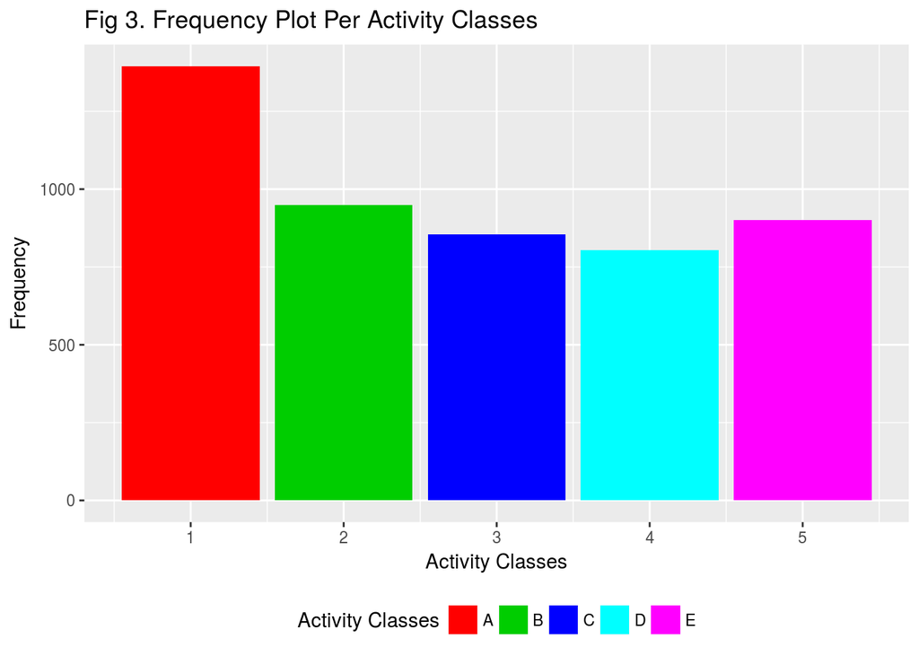

```r
freq.plot <- ggplot() +
  suppressWarnings(geom_histogram(aes(x = as.numeric(test.pca$classe),
                                      fill = test.pca$classe),
                                  stat = "count"))+
  theme(legend.position = "bottom") +
  scale_fill_manual(name = "Activity Classes", values = 2:6) +
  labs(y = 'Frequency',
       x = 'Activity Classes',
       title = paste("Fig 3. Frequency Plot Per Activity Classes"))
freq.plot
```

### B. ROC Plot

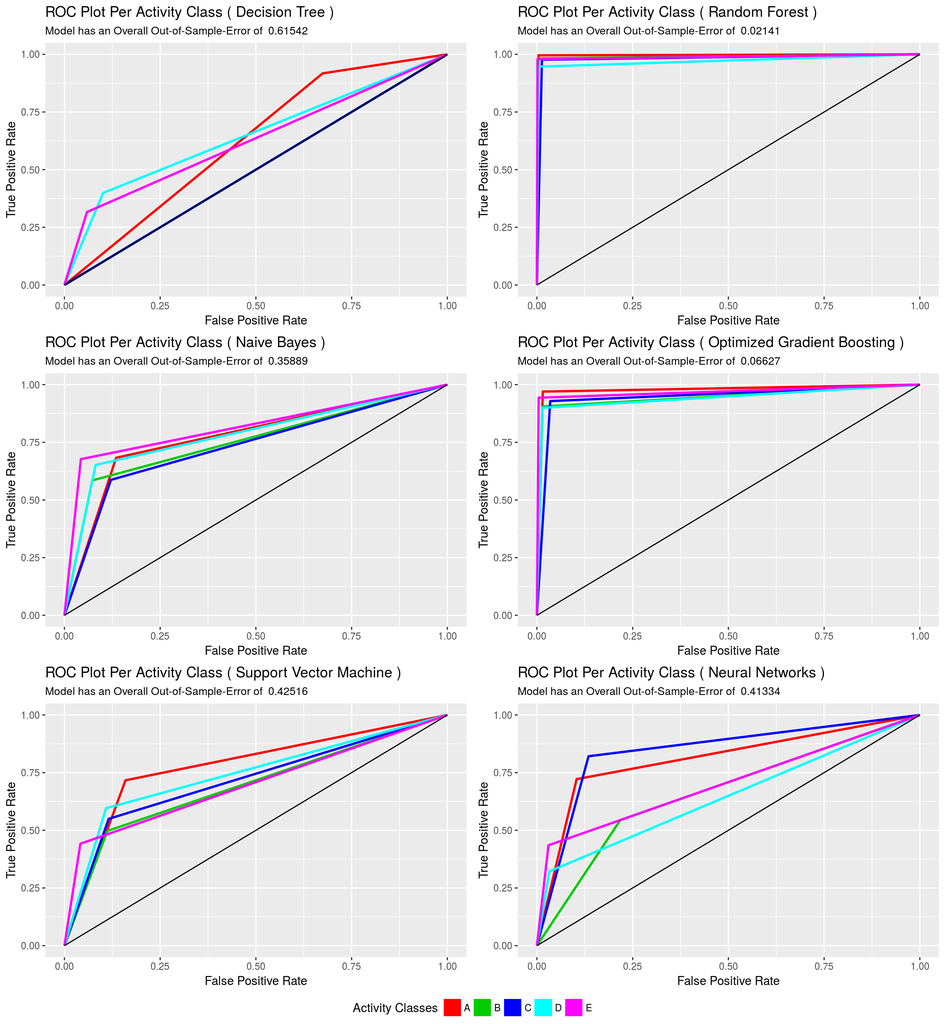

```r
# gets legend to be used in ROC plots
get.legend <- function(a.gplot) {
  tmp <- ggplot_gtable(ggplot_build(a.gplot))
  leg <- which(sapply(tmp$grobs, function(x) x$name) == "guide-box")
  legend <- tmp$grobs[[leg]]
  return(legend)
}

# plot roc curves based on confusion matrices returned by the train.and.predict
# function above.
plot.roc.curve <- function(model.name, train.and.predict.object) {
  confusion.matrix <- train.and.predict.object$confusion.matrix

  # Accuracy
  out.of.sample.error <- round(train.and.predict.object$out.of.sample.error, 5)

  by.class <- confusion.matrix$byClass[, c("Sensitivity",
                                           "Specificity")]

  p <- ggplot(x = NA, y = NA, xlim = c(0,1), ylim = c(0,1)) +
    geom_line(aes(x = c(0, 1 - by.class[1, "Specificity"], 1),
                  y = c(0, by.class[1, "Sensitivity"], 1)),
              colour = 2, lwd = 1) +
    geom_line(aes(x = c(0, 1 - by.class[2, "Specificity"], 1),
                  y = c(0, by.class[2, "Sensitivity"], 1)),
              colour = 3, lwd = 1) +
    geom_line(aes(x = c(0, 1 - by.class[3, "Specificity"], 1),
                  y = c(0, by.class[3, "Sensitivity"], 1)),
              colour = 4, lwd = 1) +
    geom_line(aes(x = c(0, 1 - by.class[4, "Specificity"], 1),
                  y = c(0, by.class[4, "Sensitivity"], 1)),
              colour = 5, lwd = 1) +
    geom_line(aes(x = c(0, 1 - by.class[5, "Specificity"], 1),
                  y = c(0, by.class[5, "Sensitivity"], 1)),
              colour = 6, lwd = 1) +
    geom_line(aes(x = c(0, 1), y = c(0, 1))) +
    labs(y = 'True Positive Rate',
         x = 'False Positive Rate',
         title = paste("ROC Plot Per Activity Class (", model.name, ")"),
         subtitle = paste("Model has an Overall Out-of-Sample-Error of ",
                          out.of.sample.error))

  p
}

# generate roc curves plot
dtree.plot <- plot.roc.curve("Decision Tree", dtree)
rforest.plot <- plot.roc.curve("Random Forest", rforest)
naivebayes.plot <- plot.roc.curve("Naive Bayes", naivebayes)
xgbtree.plot <- plot.roc.curve("Optimized Gradient Boosting", xgbtree)
svmpoly.plot <- plot.roc.curve("Support Vector Machine", svmpoly)
nnet.plot <- plot.roc.curve("Neural Networks", nnet)
custom.legend <- get.legend(freq.plot)
grid.arrange(dtree.plot, rforest.plot, naivebayes.plot, xgbtree.plot,
             svmpoly.plot, nnet.plot, custom.legend, ncol = 2, nrow = 4,
             layout_matrix = rbind(c(1, 2), c(3, 4), c(5, 6), c(7, 7)),
             heights = c(10, 10, 10, 1))
```

### D. Ensemble Modeling

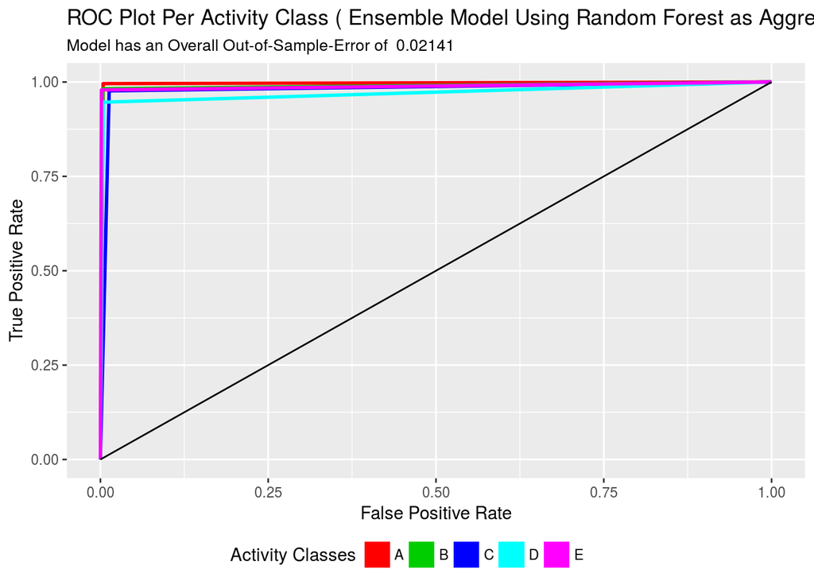

```r
# Collate predictions from models with higher accuracy
gather.predictions <- function(model, new.data = train.pca) {
  predictions <- predict(object = model, newdata = new.data)
  predictions
}
# training set for ensemble models
ensemble.training <- data.frame(rforest = gather.predictions(rforest$model),
                                xgbtree = gather.predictions(xgbtree$model),
                                classe = train.pca$classe)
# testing set for ensemble models
ensemble.testing <- data.frame(rforest = gather.predictions(rforest$model,
                                                   new.data = test.pca),
                               xgbtree = gather.predictions(xgbtree$model,
                                                   new.data = test.pca),
                               classe = test.pca$classe)

# train ensembled data using random forest as an aggregator
# no need to do cross validations
ensemble <- train.and.predict(model.method = "rf",
                              train.data = ensemble.training,
                              test.data = ensemble.testing,
                              training.parameters = trainControl(
                                method = "boot", number = 1))

# print roc plot for ensemble model
grid.arrange(plot.roc.curve("Ensemble Model Using Random Forest as Aggregator Method", ensemble), custom.legend,
             nrow = 2, heights = c(10, 1))
```

Ensemble models utilizing the results of models with low out-of-sample errors using esoteric modeling methods as aggregator will give us highly accurate models at the expense of interpretability. But given the situation where out-of-sample errors are the same for random-forest and ensemble model, the author chose the former for predicting 20 unlabeled observations.

### E. Prediction Using the Best Model for Unlabeled Dataset

This section utilizes random forest model to create prediction across 20 unlabeled observations.

```r
# generate predictions for the test data using svm poly model
# for unlabeled dataset
unlabeled.data.pca <- predict(object = preprocess.pca,
                              newdata = subset(unlabeled.data.reduced,
                                               select = -problem_id))

predict(object = rforest$model, newdata = unlabeled.data.pca)
```

```
##  [1] B A A A A E D B A A B C B A E E A B B B
## Levels: A B C D E
```

## V. Conclusion

Random Forest and ensemble methods report pretty good out-of-sample errors under generalized training parameters, deeming these as the best model for this scenario. In the Human Activity Recognition, the author err on the side of simplicity that is why the author chose random forest model to predict 20 unlabeled observations, ultimately concluding that it is possible to predict classes of movement from out-of-sample observations based on the given data.